# Do LLMs have fluid intelligence?

Lessons from competing in ARC AGI 2

[figure not shown]

Dibya Chakravorty, Debsankha Manik & Bernhard Altaner

TNG Big Techday 26

2026-05-22

# Intro

## About us

### and many thanks to everyone involved!

**Dibya Chakravorty**

[figure not shown]

- Generalist software engineer.
- Organises the [AGI Munich meetup](https://www.meetup.com/de-de/munchen-artificial-general-intelligence-meetup-group/) and [PyMunich](https://www.meetup.com/de-de/pymunich/).

**Debsankha Manik**

[figure not shown]

- Dynamical systems, graph theory; data science × discrete optimisation.
- Loves teaching.

**Bernhard Altaner**

[figure not shown]

- Thermodynamics and information processing in complex systems.
- Has local GlaDOS in his smart home.

*Supported by Nicolas Berg – co-host of the AGI Munich meetup.*

*Thank you to Somayeh Vojdani & Tariq Baig-Meininghaus for initial discussions and continued encouragement.*

*Thanks to lambda.ai for providing free credits that helped support this research.*

## What is this talk about?

### ARC-AGI 2 and our journey into forefront AI research

- **ARC-AGI 2:** **A**bstraction and **R**easoning **C**orpus for **A**rtificial **G**eneral **I**ntelligence (**2**nd edition, 2025)
- **Task:** Transform 2D `input` pixel grids into corresponding `output` grids

[interactive chart not shown]

From a few `train` grid pairs, infer a general transformation rule…

[interactive chart not shown]

…and apply it to a `test` grid!

## Easy for humans, hard for AI?

### What gives human an edge?

- ARC AGI puzzles are not well-defined **mathematically**.
- Humans still agree on a correct™ solution
- **Core human perceptive priors**: objects, groups, proximity, numbers, etc.
- **Another example:** What happens when you think about this puzzle?

[interactive chart not shown]

- A child with sandbox **experience** might solve it, but AI has never played in the mud…
- … and neither had you at some point in your life.

## ARC-AGI as a general intelligence benchmark

### What constitutes general intelligence?

Raymond Catell, 1948, defined **two aspects** of general intelligence

[figure not shown]

**General intelligence** combines **knowledge** with **adaptation**!

- ARC AGI designed to test **skill acquisition efficiency**<sup>1</sup>, a hallmark of fluid intelligence.
- Requires **In-Context-Learning**, i.e. adaption to new situations not encountered in training data.
- **Essential problem:** AI model weights are **frozen during inference**.
- So how could LLMs ever exhibit fluid intelligence?
[^1]: Francois Chollet, “ARC: A Reasoning Challenge Dataset for the Advancement of General Intelligence”, arXiv:1911.01547, 2019.

## State of the ARC in April 2025

### On the shoulders of giants

[figure not shown]

Snapshot of https://www.arcprize.org/leaderboard (Wayback Machine, 17 April 2025).

⏺ **ARC-AGI 1:** Not saturated; multiple paradigms used; reasoning models give good results, but expensive

▲ **ARC-AGI 2:** barely any scores beyond noise (~3%) level

## Challenge accepted!

### Curiosity-driven YOLO meets Dunning-Krueger

- Reasoning models seemed like an an interesting way to scale compute during test time
- Deepseek R1 and its distillates had just been released
- **Straightforward plan:**
  - **Step one:** Generate synthetic data for this domain.
  - **Step two:** Fine-tune a small open weights models and introduce reasoning like Deepseek R1 with reenforcement learning.
  - **Step three:** Profit!
- How hard could it be?

[figure not shown]

Surely this seems quite straightforward, Right?

# Main part

## Our journey

[figure not shown]

## Our journey

[figure not shown]

## Our journey

[figure not shown]

## Our journey

[figure not shown]

## Let’s begin

[figure not shown]

## Training data

[figure not shown]

## Solution trajectories

[figure not shown]

## Solution trajectories

[figure not shown]

## Solution trajectories

[figure not shown]

```
Given the following training input-output pairs, find the correct output for the given test input.

011    000
000 -> 000
000    011

222    000
020 -> 222
000    020

500
500 -> ?
000
```

```
Let me think step by step. The first example seems to be a reflection. The second example is not a reflection. It seems that clusters of numbers are actually moving downwards until they hit the last row. By that logic the answer is:

000
500
500
```

## Solution trajectories

[figure not shown]

## Rewards

[figure not shown]

## DeepSeek-R1 recipe: Reinforcement Learning

[figure not shown]

## Problem: training data shortage

[figure not shown]

## Problem: training data shortage

[figure not shown]

## Solution: make synthetic puzzles

[figure not shown]

## But how?

- The best model OpenAI o3 had near zero score on ARC AGI 2

**Hypothesis**

Even though o3 cannot **solve** puzzles with ARC AGI 2 level difficulty, it might be able to **create** difficult puzzles.

## 8000 synthetic puzzles, 671 concepts / priors

### Complex, difficult puzzles like ARC AGI 2

[figure not shown]

## 8000 synthetic puzzles, 671 concepts / priors

### Complex, difficult puzzles like ARC AGI 2

[figure not shown]

## 8000 synthetic puzzles, 671 concepts / priors

### Complex, difficult puzzles like ARC AGI 2

[figure not shown]

## Puzzle generation as program synthesis

```python
def generate_inputs(type: Literal["train", "test"]):
    """
    Generates train and test input grids.
    Usage: train_inputs = list(generate_inputs("train"))
    """
    ...

def transform(grid: list[list[int]]):
    """
    Implements the puzzle's transformation logic.
    Usage: output_grid = transform(input_grid)
    """
   ...
```

## Puzzle generation pipeline

[figure not shown]

## Puzzle generation pipeline

[figure not shown]

## Puzzle generation pipeline

[figure not shown]

## Puzzle generation pipeline

[figure not shown]

## Lessons

[figure not shown]

**Lesson 1**

Non-reasoning models are necessary for creativity, diversity and naturalness.

**Lesson 2**

Tool calling (e.g. code execution) makes reasoning models more reliable.

## Tool calling before o3 and o4-mini

### Non-reasoning models e.g. gpt-4o

[figure not shown]

## Tool calling before o3 and o4-mini

### Reasoning models e.g. o1, Claude 4

[figure not shown]

## Tool calling before o3 and o4-mini:

### Reasoning models e.g. o1, Claude 4

[figure not shown]

## Tool calling with o3 and o4-mini

### Interleaved thinking

[figure not shown]

## Interleaved thinking scales test-time compute

[figure not shown]

## Instead of DeepSeek-R1 recipe…

[figure not shown]

## Agentic RL

[figure not shown]

## Example trace

Solve this puzzle. The training examples and test inputs are already loaded in the interpreter.

Let me think. The transformation seems to be a reflection. Let me verify with code.

```
def transform(grid):
...

assert transform(train0_inp) == train0_out
```

```
AssertionError
```

There is a mismatch. Perhaps the transformation is gravity related? Let me test.

```
def transform(grid):
    ...

assert transform(train0_inp) == train0_out
```

No output

Here is the `transform` function that solves the puzzle:

```
def transform(grid):
    ...
```

## Our journey

[figure not shown]

## Side quest: learning visual priors

[figure not shown]

## ARC AGI assumes core visual priors

[figure not shown]

- 9 chambers in 3 x 3 formation, separated by gray walls
- Each chamber contains a single shape
- 5 chambers have blue plus shapes
- 2 chambers have red T shapes
- 2 chambers have green Z shapes

## Vision models expected to win, but…

- Counterintuitively, language models performed better on ARC AGI 1.
- Do language models have core visual priors?

## Language models are efficient visual learners

[figure not shown]

## Language models are efficient visual learners

[figure not shown]

## Qwen3-14B before and after fine-tuning

[figure not shown]

Held-out puzzle grid

### Before SFT (summary)

- Yellow pixels at (2,2), (2,3) …
- Navy cross at (5, 3), …
- Gray pixels at …
- Pink square at …

### After SFT (summary)

- Yellow hollow square spanning row, col (3, 2) to (5, 4) with red central pixel
- Navy hollow square spanning … with green central pixel
- Green hollow square spanning … with yellow central pixel
- Pink hollow square spanning … with blue central pixel
- Surrounded by gray walls

## Lesson

**The power of text**

Text is a surprisingly rich medium that can be used to teach about other sensory modes.

## Our journey

[figure not shown]

## Our journey

[figure not shown]

## The plan

### Reinforce the successes

[figure not shown]

## The reality with Qwen3-14B

### There’s nothing to reinforce

[figure not shown]

## Solution: distillation from successful traces

### Cold-start SFT

[figure not shown]

## Solution: distillation from successful traces

### Not all is well in the synthetic world

[figure not shown]

## Solution: distillation from successful traces

### This time, the real thing

[figure not shown]

## Example trace

Solve this puzzle. The training examples and test inputs are already loaded in the interpreter.

Let me think. The transformation seems to be a reflection. Let me verify with code.

```
def transform(grid):
...

assert transform(train0_inp) == train0_out
```

```
AssertionError
```

There is a mismatch. Perhaps the transformation is gravity related? Let me test.

```
def transform(grid):
    ...

assert transform(train0_inp) == train0_out
```

No output

Here is the `transform` function that solves the puzzle:

```
def transform(grid):
    ...
```

## Model requirements for distillation

- Open reasoning
- Interleaved thinking capable
- Intelligent enough to get 10% on ARC AGI 2

### Reality

- No model satisfied these requirements
- Closest match: **GPT OSS 120B**
  - Expected to get 0% on ARC AGI 2

## GPT OSS 120B seemed dumb

### Something was fundamentally off

- Invalid tool calls
- Server errors, most likely originating from the inference engine
- No interleaved thinking

## Inference providers we tried

[figure not shown]

## Inference engines we tried

### vLLM and SGLang on Lambda AI H100 and GH200 GPUs

[figure not shown]

## Harmony chat template

- OpenAI didn’t follow existing chat template standards like **ChatML** with GPT OSS
- They released their own standard: **Harmony**

## ChatML vs. Harmony

### System / developer message

ChatML

```
<|im_start|>system
# Tools

<tools>
{"type": "function", "function": {"name": "get_weather", "description": "Get weather for a city", "parameters": {"type": "object", "properties": {"city": {"type": "string"}, "unit": {"type": "string", "enum": ["celsius", "fahrenheit"]}}, "required": ["city"]}}}
</tools>
```

Harmony

```
<|start|>developer<|message|># Tools
## functions
namespace functions {
// Get weather for a city
type get_weather = (_: {
  city: string,
  unit?: "celsius" | "fahrenheit", // default: celsius
}) => any;
} // namespace functions<|end|>
```

## ChatML vs. Harmony

### User message

ChatML

```
<|im_start|>user
What's the weather in Tokyo?<|im_end|>
```

Harmony

```
<|start|>user<|message|>What's the weather in Tokyo?<|end|>
```

## ChatML vs. Harmony

### Reasoning

ChatML

```
<|im_start|>assistant
</think>
User wants Tokyo weather. Need to call get_weather function.
</think>
```

Harmony

```
<|start|>assistant<|channel|>analysis<|message|>User wants Tokyo weather. Need to call get_weather function.<|end|>
```

## ChatML vs. Harmony

### Tool call preamble

ChatML

```
I'll check the current weather in Tokyo for you.
```

Harmony

```
<|start|>assistant<|channel|>commentary<|message|>I'll check the current weather in Tokyo for you.<|end|>
```

## ChatML vs. Harmony

### Tool call

ChatML

```
<tool_call>
{"name": "get_weather", "arguments": {"city": "Tokyo", "unit": "celsius"}}
</tool_call><|im_end|>
```

Harmony

```
<|start|>assistant<|channel|>commentary to=functions.get_weather<|constrain|>json<|message|>{"city": "Tokyo", "unit": "celsius"}<|call|>
```

## ChatML vs. Harmony

### Tool response

ChatML

```
<|im_start|>user
<tool_response>
{"temperature": 22, "condition": "partly cloudy", "humidity": 65}
</tool_response>
```

Harmony

```
<|start|>functions.get_weather to=assistant<|channel|>commentary<|message|>{"temperature": 22, "condition": "partly cloudy", "humidity": 65}<|end|>
```

## ChatML vs. Harmony

### Final assistant response

ChatML

```
<|im_start|>assistant
The current weather in Tokyo is 22°C with partly cloudy skies and 65% humidity.<|im_end|>
```

Harmony

```
<|start|>assistant<|channel|>final<|message|>The current weather in Tokyo is 22°C with partly cloudy skies and 65% humidity.<|return|>
```

## Harmony chat template bug

- Both vLLM and SGLang had wrong implementations of Harmony
- Inference providers who used these inference engines inherited the bugs
- We patched vLLM and started using our patched version

## GPT OSS after fix

### An interleaved thinking pro

[figure not shown]

## GPT OSS after fix

### Plain CoT vs interleaved thinking

[figure not shown]

## State of the art results

[figure not shown]

# Conclusions

## Our journey

[figure not shown]

## At the bleeding edge

### The frontier may be closer than it appears to be

- Tool call + interleaved thinking ⟶ orchestrating own **code execution sandbox** (Q2’25).
- Finetuning for tool calling, limited VRAM ⟶ **YOLO libraries** (unsloth) (Q2’25).
  - Manually fixing chat template for Qwen3.
- (Non redacted) interleaved thinking traces ⟶ **Patching vLLM** and hosting **own GPT-OSS model** (Q4’25).
- Vibe coding ⟶ **Autonomous** task completion with single prompt (with tool calls) (Q4’25).

## Lessons learned along the way

### Taking the birds eye view

- **Tool use + reasoning** ⟶ significant jump in LLM performance in reasoning tasks.
  - Python (or similar tools) **grounds the model** - filter bad hypotheses early and **replan**.
  - Labs underreported their flagship models’ performance on ARC **because they evaluated without tool use**.
- **Small / open-weight models punch above their reputation**
  - We roughly **4×**’d score on `gpt-oss-120b` with the right harness.
- **Synthetic data isn’t magic**: Have to watch out for distribution shift.
  - “Shortcut-y” traces skipped the messy reality of wrong hypotheses and recovery — undermines performance in inference time where replanning is necessary.

[figure not shown]

## Practical take-home messages

### For working effectively with modern LLMs

- **Don’t over engineer agentic harnesses** (just like prompts).
  - Complex harnesses generalize poorly, especially across **tasks with varying difficulty** levels.
  - LLMs armed with reasoning+tool use can **dynamically adapt compute** to the task: *imposing a rigid structure hamstrings them*.
- **Simplicity + verification**
  - Tell the model how to **deterministically evaluate** its output against the goal (partly why models struggle at open-ended creative tasks).
  - But careful: LLMs will **hack the evaluator function** if they can.
- **There’s plenty of room for innovation outside frontier labs**
  - Models internalize more and more abilities → **harnesses must continuously evolve**.
  - **Limits of innate abilities** of models → exactly where **things get exciting**!
  - **Open weight models** catch up to frontier models after a while.

## What about the water filling puzzle?

### Back to the (`python`) sandbox

*Using GPT 5.5 XHigh*

Puzzle

understands

Visual features

"water settling into crevices..."  
"...under gravity"

develops

Awareness of walls and flow dynamics

"flows around walls..."  
"...spills over a wall"

transforms grid

Text representation

```
........WW
........WW
.......GWW
.......GWW
.......GWW
.....G.GWW
.....G.GWW
....RG.GWW
....RG.GWW
.RRRRGGGWW
```

hypothesizes

Flow dynamics

"drops straight until it hits an obstacle"  
"...may slide down the diagonal"

Trial solution using simulation

*checks gravity direction, horizontal flow rule bad → oscillations*

adds tracing

Oscillation bug found

*‘Fixes’ by left-over-right tie breaking*

applies solution on

Test example

*left-over-right tie breaking needed to avoid infinite loop*

submits

Solution

## Simple sandbox physics solves the puzzle…

### …on its own devices

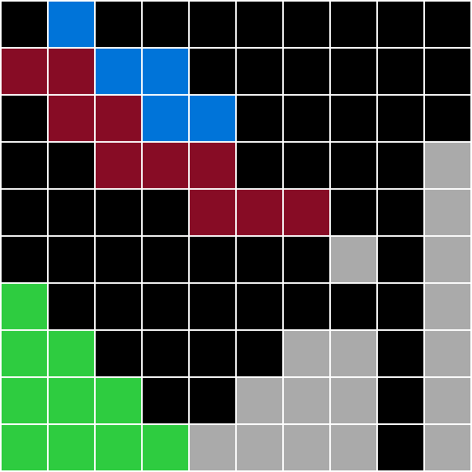

**What do you think? Do LLMs have fluid intelligence?**

## Good news for (us) physicists…

### …still much to play with and discover (like parity symmetry)

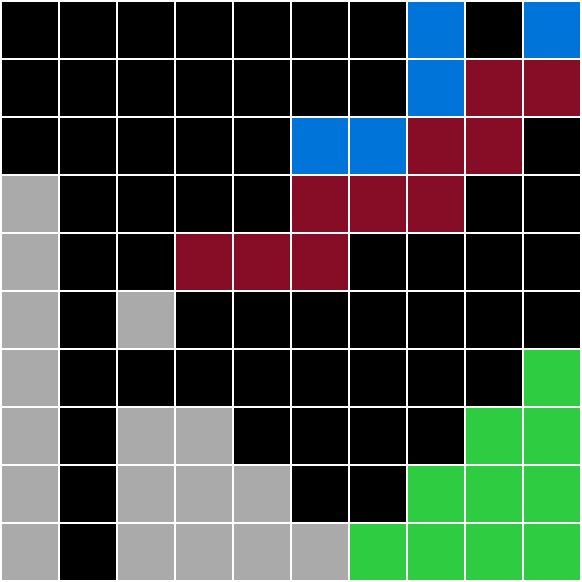

**Thank you for your attention!**

**Any Questions?**